# Population Ecology

## Things to know (#s)

- **#Density Matters**
- **#Life History Traits (demography)**
- **#Growth Types**

## The big picture: The environment influences populations

- **Review: What is a population?**
- **Biotic and abiotic factors affect population dynamics**
  - abundance, spacing, & age structure
- **Population growth can be ‘modeled’**
  - tracking births & deaths can show trends
- **Density (#/area) matters**
  - crowdedness impacts population growth

[figure not shown]

## Populations often described by their boundaries

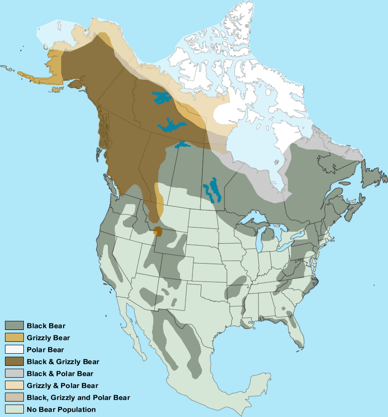

[figure not shown]

## Measuring population size and density

- **May be possible to count all individuals**
  - large mammals, animals in small habitats
- **More often impractical or impossible to count all individuals**
  - indirect estimates are needed
  - dusk deer surveys in Biol 303
  - mark and recapture in Biol 303
- **Population size and density is dynamic**
  - migration in and out of populations
  - births & deaths
  - motility

[figure not shown]

## Densities vary within a population

**The density of these populations is the same but their ecology (abiotic/biotic) differs**

[figure not shown]

## Tracking population trends through time (demography)

- **Reproductive rates vs Survivorship**
  - key for conservation
- **Cohorts: group of individuals born at the same time**
  - how many of one age-group *survive* to the next age level?
  - what age/s does reproduction occur?
- **Female power!**
  - only females produce offspring
  - how many *females give rise to new females*`?
  - how many years do females reproduce?

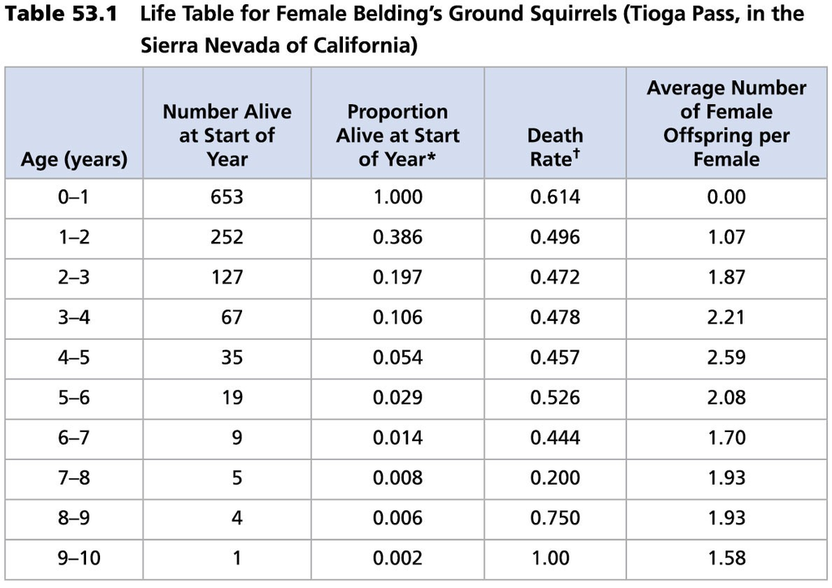

## Trade offs exists between reproduction and survival

- **Frequency of reproduction**
- **Number of offspring**
- **Investment into parental care**

**Combined, the traits represents an organism’s *life history***

1. Age at first reproduction?
2. How often reproduction occurs?
3. How many offspring are created?
4. What happens to offspring after birth?

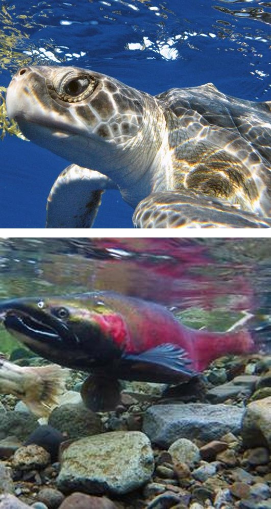

## Trade offs exists between reproduction and survival

- **Frequency of reproduction**
- **Number of offspring**
- **Investment into parental care**

**Combined, the traits represents an organism’s *life history***

1. Age at first reproduction?
2. How often reproduction occurs?
3. How many offspring are created?
4. What happens to offspring after birth?

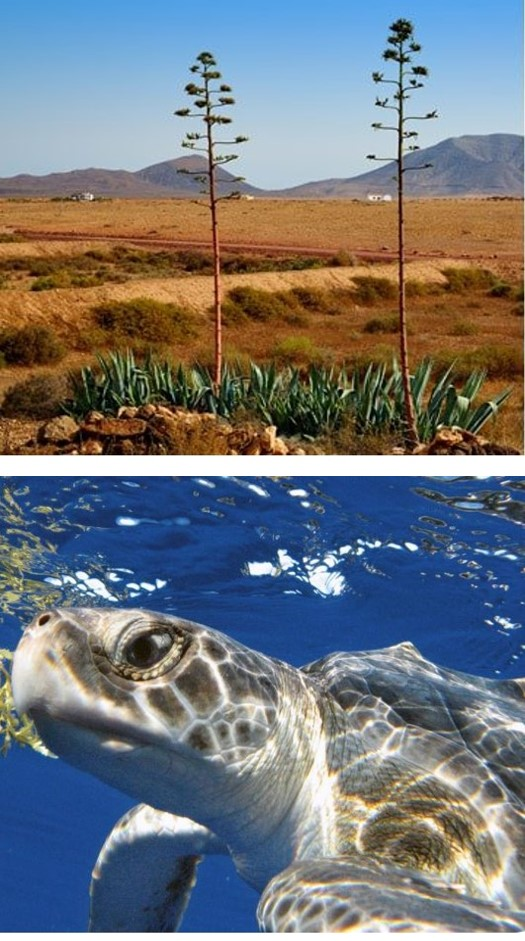

## Trade offs exists between reproduction and survival

- **Frequency of reproduction**
- **Number of offspring**
- **Investment into parental care**

**Combined, the traits represents an organism’s *life history***

1. Age at first reproduction?
2. How often reproduction occurs?
3. How many offspring are created?
4. What happens to offspring after birth?

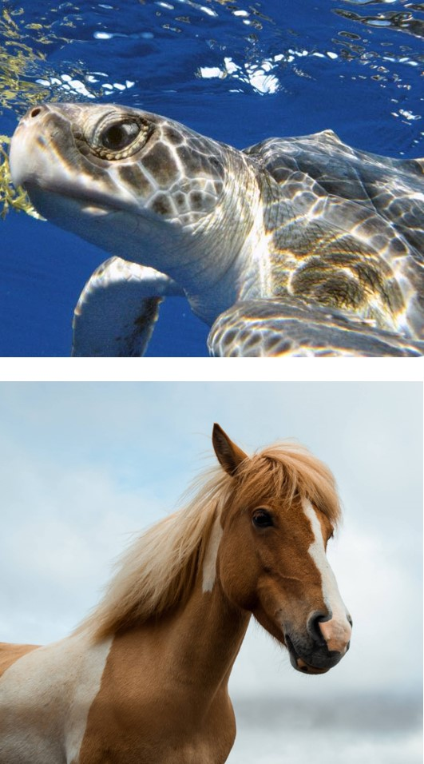

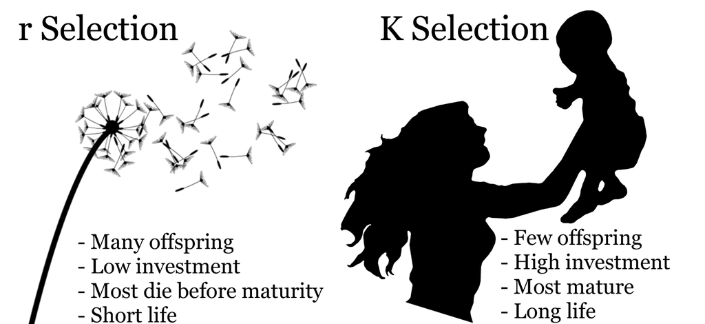

## Patterns of survivorship in natural populations

[figure not shown]

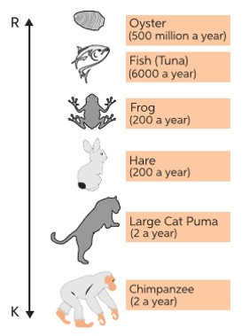

## Populations grow fast when resources are abundant

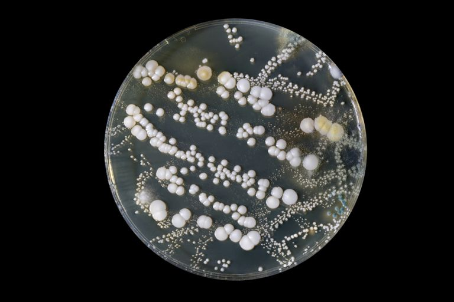

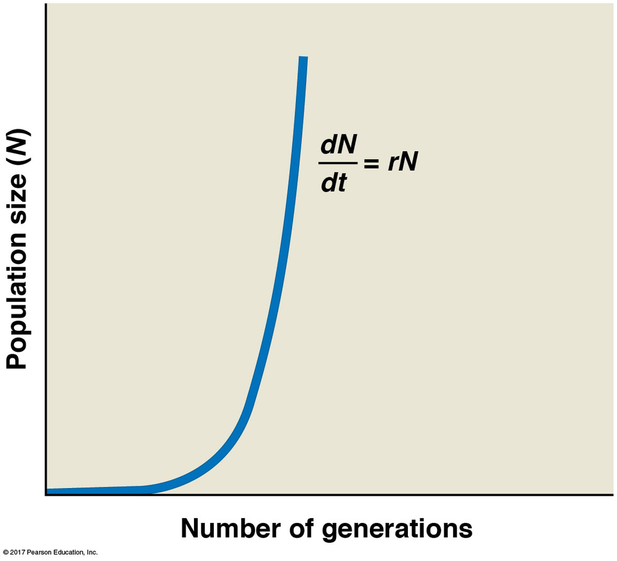

## Can we predict changes in population size?

[figure not shown]

## Elephants in Kruger National Park (Exponential Growth)

[figure not shown]

## Resources rarely remain non-limiting

[figure not shown]

## Density in populations matter (carrying capacity)

- **Why do populations stop growing?**
- **Density dependent factors = crowdedness**
  - resources, predator-prey
  - disease, waste becomes toxic
- **Population density works as a negative feedback for predator-prey populations**
  - creates a cyclical relationship where both populations are regulated by the other’s density.

[figure not shown]

## What factors are *density independent*?

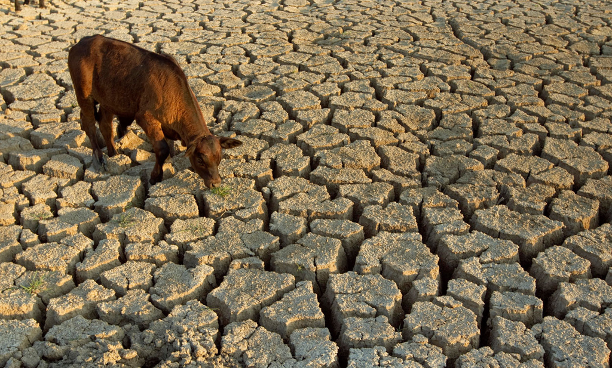

## Patterns in human population

[figure not shown]

[figure not shown]

## Patterns in human population: Age structure

[figure not shown]

## Patterns in human population: Density and carrying capacity

[figure not shown]